# DaliScope WorkedExample1 - HTML example output

DaliScope — WorkedExample1: HTML example output

Browse saved figures, tables and text without running code. This is an author-supplied export, originally named `SignatureTest.html`; its execution version was not recorded. This historical page was not regenerated for v0.1.9; its saved dom_5_FOLD count (1,176) differs from the current notebook run (1,173).

Python-backed controls require the notebook. Embedded 3D views depend on an external viewer and browser WebGL support.

Restart kernel twice to run the notebook...

```python
# Installs daliscope, all core requirements, and notebook extras (ipympl)
%pip install -e "..[notebook]" -q
```

```python
import pandas as pd
from IPython.display import display

import daliscope
import daliscope.core.project
import daliscope.optics.histograms
import daliscope.analysis.data_preview
import daliscope.analysis.occupancy
import daliscope.analysis.structal_similarity # for cluster evaluation
import daliscope.widgets.pairwise_py3Dmol
import daliscope.optics.modules_sunburst
import daliscope.analysis.communities
import daliscope.analysis.pfam_stats
import daliscope.optics.py3Dmol_viewer
import daliscope.optics.domnet_viewer
import daliscope.analysis.CH_cluster

from daliscope.analysis.data_preview import show_heading
```

# A multidomain Query: from architecture to sequence signatures

In this worked example, we use a multidomain Query protein to explore how structural and sequence features can be traced from an individual protein into a broader population.

We begin by examining the Query's domain architecture and structural relationships, then use sequence-level analyses to identify conserved features within selected domains. These observations lead to a discrete sequence signature, which we use to search the raw dataset and determine where the corresponding feature occurs across the population. Finally, we summarize the functional descriptions associated with the resulting modules.

The example therefore follows a progression from **domain architecture and structural context, through sequence conservation, to population-wide pattern search and functional interpretation**, illustrating how the different DaliScope analyses can be combined into a single investigation.

# Explore the Dali search results

Structural similarity at a glance

Once the raw Dali data are loaded, DaliScope presents the search results as a scatterplot of **Z-score versus query coverage**. Together, these provide a first view of the quality and extent of each structural match.

The two measures are generally correlated. The Dali Z-score summarizes structural similarity based on the correspondence of intramolecular distances: for a given number of aligned residues, a more precise structural match produces a higher Z-score.

The plot uses two complementary colour schemes:

- **Sequence identity** indicates how the structural matches relate to what could be found by sequence-based searches: from clear sequence homologs, through the *twilight zone* where structural alignment becomes particularly informative, to cases where structural similarity is difficult to detect from sequence alone.
- **Z-score regimes** provide a heuristic indication of the strength of the structural match. These regimes work well for typical cases, but their interpretation depends on the query structure: optimal thresholds can vary with protein size and shape.

As a first step, this view gives us a map of the structural neighbourhood of the Query and helps identify which hits warrant closer inspection.

Loading data

```
Pack loaded: 838177 coord rows, 33600 segments, 1584 alignments, Query.pdb: yes
  Superimpositions: 1573/1573 succeeded
  Pfam: 1573/1573 alignments assigned
  Pfam domains: 1485/1573 targets
  Clan domains: 1485/1573 targets
  Pileups: 1573 sequ, 1573 dssp
Silver built: 1573 alignments (11 dropped), query length=1724
✓ Registered 'dom_0-1724': 1573 alignments
  Default view 'dom_0-1724' registered
```

Top hits

|  | Target | Z-Score | RMSD | aln_len | Description | % Id |
| --- | --- | --- | --- | --- | --- | --- |
| 1 | c9kdA | 61.5 | 0.0 | 724 | RAT:AF-M0RDF1-F1 LYSINE DEMETHYLASE 3B; | 100 |
| 2 | gbsaA | 59.0 | 9.8 | 664 | MOUSE:AF-Q6ZPY7-F1 LYSINE-SPECIFIC DEMETHYLASE 3B; | 96 |
| 3 | fbxwA | 58.5 | 2.4 | 641 | HUMAN:AF-Q7LBC6-F1 LYSINE-SPECIFIC DEMETHYLASE 3B; | 93 |

Query information

```
Identifier: c9kdA
Length: 1724
Description:  RAT:AF-M0RDF1-F1 LYSINE DEMETHYLASE 3B;
PUU domains: 225-317_332-475_497-761_775-830_1098-1177_1199-1323, 1-224_318-331_476-496_762-774, 831-1097_1178-1198_1324-1724
```

Creating filtered subsets

```
  Subset 'FILTERED_0': 380/1573 rows
  Subset 'FILTERED_1': 58/1573 rows
```

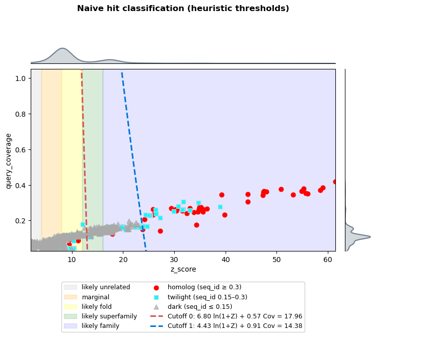

dom_0-1724 ( n = 1573 )

```
Initializing heavy assets...
Generating RGB Heatmap array...
```

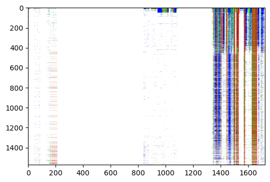

```python
# Load data
# The data pack must be uploaded to the Notebook host. Default data files are in DaliScope/notebooks/data.
pack_path = 'data/ZN_full.tar.gz'

# 1. Initialize & Preview Top Hits
project, FULL_DF, FULL_VIEW = daliscope.analysis.data_preview.load_and_inspect_project(pack_path)

# 2. Query metadata
show_heading("Query information")
tmp = list(project._query_meta.iloc[0])
puu_domains = tmp[5]
print(f"""
Identifier: {tmp[0]}
Length: {tmp[1]}
Description: {tmp[4]}
PUU domains: {puu_domains}
""")

# 3. Plot Landscape
fig = daliscope.analysis.data_preview.plot_dali_hits_with_boundaries(
    FULL_DF,
    daliscope.analysis.data_preview.build_and_register_subsets(project, FULL_DF, FULL_VIEW)
)

# 4. Project structural alignments onto Query positions
project.viz.plot_msa(FULL_VIEW, 0, project.query_length, plot_type='heatmap', data_col='dssp_pileup')
```

> The plot shows a typical mix of sequence identity regimes: homologs have the highest Z-scores, followed by twilight hits. The large peak with dark hits can contain genuine biologically interesting hits, and noise. >DaliScope automatically created two subsets wihch bisect the plane at valleys in the density distribution. Sometimes - but far from always - the subsets correspond to families or superfamilies. These automatically generated subsets are called FILTERED_0 and FILTERED_1.

> The structural alignment shows mutliple mutually exlusive blocks - the Query protein consists of multiple domains, some with more hits than others. Refined superimposition and accurate annotation need to be applied on a per-domain basis.

## Structural Coherence & Weighted Alignment

Dali alignments optimize intramolecular distance similarity rather than spatial coordinates. Consequently, distant $\text{C}_\alpha$ atoms at similar radial distances can inflate global RMSD values and disrupt rigid-body superimpositions.

To restore spatial coherence within specified domains, we apply a two-step weighted superimposition:

1. **Domain Clipping:** Assigns zero weight to off-domain aligned positions.
2. **Occupancy Weighting:** Downweights highly flexible regions (e.g., irregular loops) to prevent them from distorting core alignments.

In the secondary-structure-colored alignment plot (blue $\alpha$-helices, red $\beta$-strands, green loops), rigid domains appear as distinct structural blocks. Using this visual reference, we define five contiguous domains: `1–149`, `150–214`, `840–920`, `921–1100`, and `1343–1722`.

```python
# Prepare PDB structure string
pdb_string = daliscope.optics.py3Dmol_viewer.xyz_to_ca_pdb(project.query_ca_coords, project.query_sequence)

custom_domains = "1-149, 150-214, 840-920, 921-1100, 1343-1722"

# Initialize and render interactive viewer
viewer = daliscope.optics.domnet_viewer.DomNetViewer(
    pdb_text=pdb_string,
    domain_string=custom_domains if custom_domains else puu_domains,
    normal_radius=0.65,
    highlight_radius=0.60,
)

print("""
Domain Syntax example: "1-100, 101-300_400-500, 301-399" means
    Domain 1: 1–100;
    Domain 2 [discontiguous]: 101–300 + 400–500;
    Domain 3: 301–399

IF the viewer throws a JavaScript error, refresh your browser (CTRL-R) and rerun this code cell.
If the canvas is blank, re-run this cell

You can play around editing and visualizing domain boundaries, though this worked example will use
the initial domain boundaries for downstream analyses.
""")

viewer.display()
```

```
Domain Syntax example: "1-100, 101-300_400-500, 301-399" means
    Domain 1: 1–100;
    Domain 2 [discontiguous]: 101–300 + 400–500;
    Domain 3: 301–399

IF the viewer throws a JavaScript error, refresh your browser (CTRL-R) and rerun this code cell.
If the canvas is blank, re-run this cell

You can play around editing and visualizing domain boundaries, though this worked example will use
the initial domain boundaries for downstream analyses.
```

```
VBox(children=(Text(value='1-149, 150-214, 840-920, 921-1100, 1343-1722', description='Domains:', layout=Layou…
```

```
<daliscope.optics.domnet_viewer.DomNetCanvas object at 0x7fc4aca7a5d0>
```

```
✓ Registered 'dom_1': 180 alignments
✓ Registered 'dom_2': 224 alignments
✓ Registered 'dom_3': 140 alignments
✓ Registered 'dom_4': 210 alignments
✓ Registered 'dom_5': 1481 alignments
```

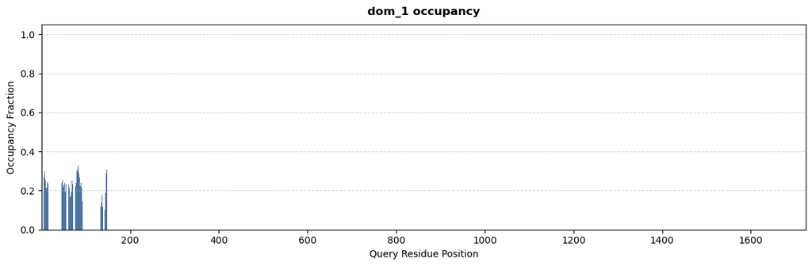

```
  Subset 'dom_1_FOLD': 16/180 rows
```

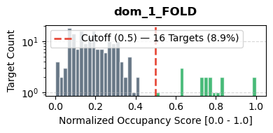

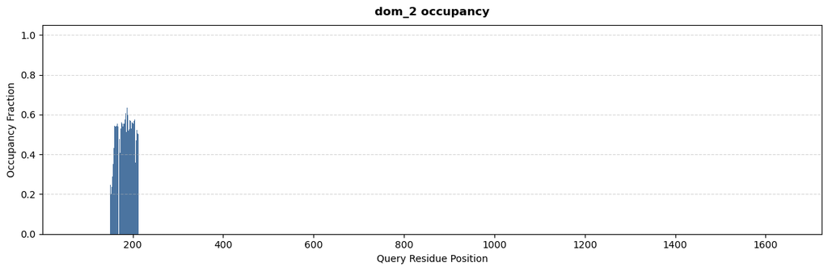

```
  Subset 'dom_2_FOLD': 111/224 rows
```

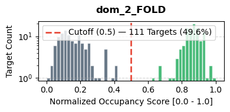

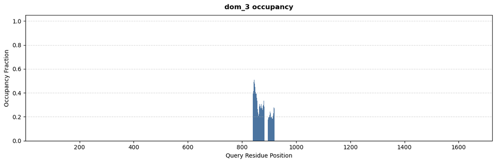

```
  Subset 'dom_3_FOLD': 18/140 rows
```

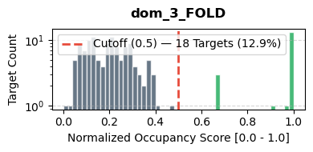

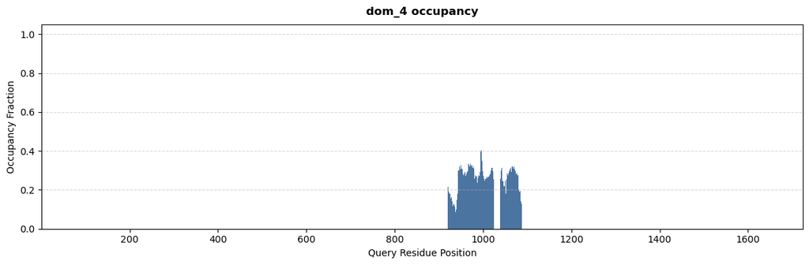

```
  Subset 'dom_4_FOLD': 51/210 rows
```

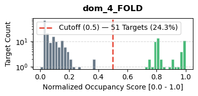

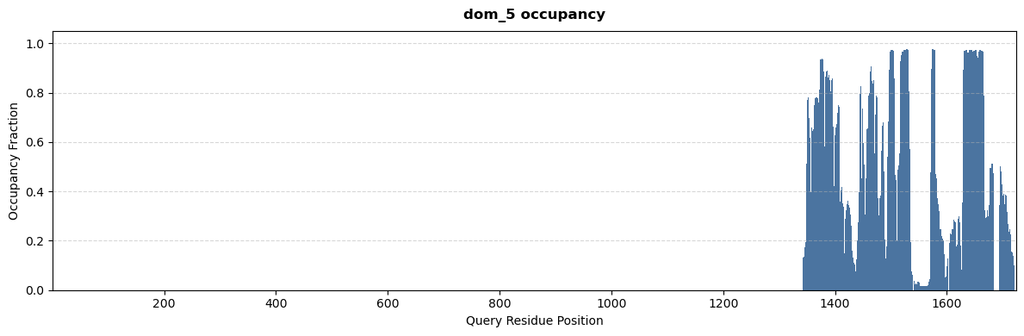

```
  Subset 'dom_5_FOLD': 1176/1481 rows
```

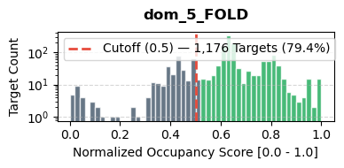

Which parts of the protein correspond to distinct structural folds?

```
Dataset Key:
  d_0 -> dom_1_FOLD 16
  d_1 -> dom_2_FOLD 111
  d_2 -> dom_3_FOLD 18
  d_3 -> dom_4_FOLD 51
  d_4 -> dom_5_FOLD 1176
```

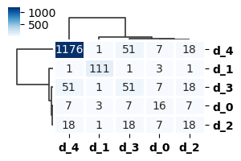

```python
# 2. Register clipped parent domain. Updates superimpositions and alignment metrics (except Z-score which stays global)
daliscope.mechanics.metrics.register_multiple_domains(
    domain_string=custom_domains,
    project=project,
    custom_name="dom"
)

# Process each registered domain view
view_list = []
for i in [1,2,3,4,5]:
    view_list.append(f"dom_{i}")

for view_name in view_list:
    daliscope.analysis.occupancy.create_fold_subset(project, view_name, show_plot=True, cutoff=0.5)

show_heading("Which parts of the protein correspond to distinct structural folds?")
shared_matrix = daliscope.analysis.occupancy.get_fold_matrix(project, view_list)

# Render heatmap
daliscope.analysis.occupancy.plot_shared_matrix_heatmap(shared_matrix, figsize=(3,2))
```

> dom_3_FOLD always co-occurs with dom_4_FOLD, and dom_4 always co-occurs with dom_5_FOLD.

> dom_1_FOLD and dom_2_FOLD are evolutionarily mobile modules: they recombine with target proteins that share no other domains with our Query protein.

# What do existing domain classifications tell us?

```python
# 1. Table view
for i in [1,2,3,4,5]:
    view_name = f"dom_{i}_FOLD"
    show_heading(view_name)
    daliscope.analysis.pfam_stats.pfam_counts(view_name, project, k=10, print_tables = True)
```

dom_1_FOLD

```
Largest families in dom_1_FOLD population
```

| pfam | count | clan | clan_short | short | name |
| --- | --- | --- | --- | --- | --- |
| Unassigned | 4 | NaN | NaN | NaN | NaN |
| [PF22989](https://www.ebi.ac.uk/interpro/entry/pfam/PF22989/) | 4 | [CL0010](https://www.ebi.ac.uk/interpro/set/pfam/CL0010/) | SH3 | DUF7030 | Domain of unknown function (DUF7030) |
| [PF22987](https://www.ebi.ac.uk/interpro/entry/pfam/PF22987/) | 3 | [CL0010](https://www.ebi.ac.uk/interpro/set/pfam/CL0010/) | SH3 | Tudor_KDM3B | Lysine-specific demethylase 3B, tudor domain |
| [PF05641](https://www.ebi.ac.uk/interpro/entry/pfam/PF05641/) | 2 | [CL0010](https://www.ebi.ac.uk/interpro/set/pfam/CL0010/) | SH3 | Agenet | Agenet domain |
| [PF02513](https://www.ebi.ac.uk/interpro/entry/pfam/PF02513/) | 1 | [CL0010](https://www.ebi.ac.uk/interpro/set/pfam/CL0010/) | SH3 | Spin-Ssty | Spin/Ssty Family |
| [PF11717](https://www.ebi.ac.uk/interpro/entry/pfam/PF11717/) | 1 | [CL0010](https://www.ebi.ac.uk/interpro/set/pfam/CL0010/) | SH3 | Tudor-knot | RNA binding activity-knot of a chromodomain |
| [PF13650](https://www.ebi.ac.uk/interpro/entry/pfam/PF13650/) | 1 | [CL0129](https://www.ebi.ac.uk/interpro/set/pfam/CL0129/) | Peptidase_AA | Asp_protease_2 | Aspartyl protease |

```
Largest superfamilies in dom_1_FOLD population
```

| clan | count | clan_short |
| --- | --- | --- |
| [CL0010](https://www.ebi.ac.uk/interpro/set/pfam/CL0010/) | 11 | SH3 |
| Unassigned | 4 | NaN |
| [CL0129](https://www.ebi.ac.uk/interpro/set/pfam/CL0129/) | 1 | Peptidase_AA |

dom_2_FOLD

```
Largest families in dom_2_FOLD population
```

| pfam | count | clan | clan_short | short | name |
| --- | --- | --- | --- | --- | --- |
| Unassigned | 63 | NaN | NaN | NaN | NaN |
| [PF00855](https://www.ebi.ac.uk/interpro/entry/pfam/PF00855/) | 6 | [CL0010](https://www.ebi.ac.uk/interpro/set/pfam/CL0010/) | SH3 | PWWP | PWWP domain |
| [PF21743](https://www.ebi.ac.uk/interpro/entry/pfam/PF21743/) | 3 | [CL0010](https://www.ebi.ac.uk/interpro/set/pfam/CL0010/) | SH3 | PTM_DIR17_Tudor | PTM/DIR17-like, Tudor domain |
| [PF00102](https://www.ebi.ac.uk/interpro/entry/pfam/PF00102/) | 2 | [CL0031](https://www.ebi.ac.uk/interpro/set/pfam/CL0031/) | Phosphatase | Y_phosphatase | Protein-tyrosine phosphatase |
| [PF00567](https://www.ebi.ac.uk/interpro/entry/pfam/PF00567/) | 2 | [CL0010](https://www.ebi.ac.uk/interpro/set/pfam/CL0010/) | SH3 | TUDOR | Tudor domain |
| [PF07653](https://www.ebi.ac.uk/interpro/entry/pfam/PF07653/) | 2 | [CL0010](https://www.ebi.ac.uk/interpro/set/pfam/CL0010/) | SH3 | SH3_2 | Variant SH3 domain |
| [PF06003](https://www.ebi.ac.uk/interpro/entry/pfam/PF06003/) | 2 | [CL0010](https://www.ebi.ac.uk/interpro/set/pfam/CL0010/) | SH3 | SMN_Tudor | Survival motor neuron protein (SMN), Tudor domain |
| [PF02736](https://www.ebi.ac.uk/interpro/entry/pfam/PF02736/) | 2 | [CL0010](https://www.ebi.ac.uk/interpro/set/pfam/CL0010/) | SH3 | Myosin_N | Myosin N-terminal SH3-like domain |
| [PF00385](https://www.ebi.ac.uk/interpro/entry/pfam/PF00385/) | 1 | [CL0010](https://www.ebi.ac.uk/interpro/set/pfam/CL0010/) | SH3 | Chromo | Chromo (CHRromatin Organisation MOdifier) domain |
| [PF00924](https://www.ebi.ac.uk/interpro/entry/pfam/PF00924/) | 1 | [CL0986](https://www.ebi.ac.uk/interpro/set/pfam/CL0986/) | Sm-like | MS_channel_2nd | Mechanosensitive ion channel, beta-domain |

```
Largest superfamilies in dom_2_FOLD population
```

| clan | count | clan_short |
| --- | --- | --- |
| Unassigned | 63 | NaN |
| [CL0010](https://www.ebi.ac.uk/interpro/set/pfam/CL0010/) | 40 | SH3 |
| [CL0031](https://www.ebi.ac.uk/interpro/set/pfam/CL0031/) | 2 | Phosphatase |
| [CL0266](https://www.ebi.ac.uk/interpro/set/pfam/CL0266/) | 1 | PH |
| [CL0021](https://www.ebi.ac.uk/interpro/set/pfam/CL0021/) | 1 | OB |
| [CL0893](https://www.ebi.ac.uk/interpro/set/pfam/CL0893/) | 1 | AD |
| PF04283 | 1 | NaN |
| PF06584 | 1 | NaN |
| PF18701 | 1 | NaN |

dom_3_FOLD

```
Largest families in dom_3_FOLD population
```

| pfam | count | clan | clan_short | short | name |
| --- | --- | --- | --- | --- | --- |
| Unassigned | 18 | NaN | NaN | NaN | NaN |

```
Largest superfamilies in dom_3_FOLD population
```

| clan | count | clan_short |
| --- | --- | --- |
| Unassigned | 18 | NaN |

dom_4_FOLD

```
Largest families in dom_4_FOLD population
```

| pfam | count | clan | clan_short | short | name |
| --- | --- | --- | --- | --- | --- |
| Unassigned | 48 | NaN | NaN | NaN | NaN |
| [PF10497](https://www.ebi.ac.uk/interpro/entry/pfam/PF10497/) | 3 | PF10497 | NaN | zf-4CXXC_R1 | Zinc-finger domain of monoamine-oxidase A repressor R1 |

```
Largest superfamilies in dom_4_FOLD population
```

| clan | count | clan_short |
| --- | --- | --- |
| Unassigned | 48 | NaN |
| PF10497 | 3 | NaN |

dom_5_FOLD

```
Largest families in dom_5_FOLD population
```

| pfam | count | clan | clan_short | short | name |
| --- | --- | --- | --- | --- | --- |
| [PF14226](https://www.ebi.ac.uk/interpro/entry/pfam/PF14226/) | 382 | [CL0029](https://www.ebi.ac.uk/interpro/set/pfam/CL0029/) | Cupin | DIOX_N | non-haem dioxygenase in morphine synthesis N-terminal |
| [PF02373](https://www.ebi.ac.uk/interpro/entry/pfam/PF02373/) | 221 | [CL0029](https://www.ebi.ac.uk/interpro/set/pfam/CL0029/) | Cupin | JmjC | JmjC domain, hydroxylase |
| [PF03171](https://www.ebi.ac.uk/interpro/entry/pfam/PF03171/) | 207 | [CL0029](https://www.ebi.ac.uk/interpro/set/pfam/CL0029/) | Cupin | 2OG-FeII_Oxy | 2OG-Fe(II) oxygenase superfamily |
| [PF13621](https://www.ebi.ac.uk/interpro/entry/pfam/PF13621/) | 126 | [CL0029](https://www.ebi.ac.uk/interpro/set/pfam/CL0029/) | Cupin | Cupin_8 | Cupin-like domain |
| [PF05721](https://www.ebi.ac.uk/interpro/entry/pfam/PF05721/) | 79 | [CL0029](https://www.ebi.ac.uk/interpro/set/pfam/CL0029/) | Cupin | PhyH | Phytanoyl-CoA dioxygenase (PhyH) |
| Unassigned | 69 | NaN | NaN | NaN | NaN |
| [PF08007](https://www.ebi.ac.uk/interpro/entry/pfam/PF08007/) | 51 | [CL0029](https://www.ebi.ac.uk/interpro/set/pfam/CL0029/) | Cupin | JmjC_2 | JmjC domain |
| [PF13640](https://www.ebi.ac.uk/interpro/entry/pfam/PF13640/) | 15 | [CL0029](https://www.ebi.ac.uk/interpro/set/pfam/CL0029/) | Cupin | 2OG-FeII_Oxy_3 | 2OG-Fe(II) oxygenase superfamily |
| [PF17811](https://www.ebi.ac.uk/interpro/entry/pfam/PF17811/) | 8 | PF17811 | NaN | JHD | Jumonji helical domain |
| [PF07350](https://www.ebi.ac.uk/interpro/entry/pfam/PF07350/) | 5 | [CL0029](https://www.ebi.ac.uk/interpro/set/pfam/CL0029/) | Cupin | Gig2-like | Gig2-like |

```
Largest superfamilies in dom_5_FOLD population
```

| clan | count | clan_short |
| --- | --- | --- |
| [CL0029](https://www.ebi.ac.uk/interpro/set/pfam/CL0029/) | 1093 | Cupin |
| Unassigned | 69 | NaN |
| PF17811 | 8 | NaN |
| [CL0229](https://www.ebi.ac.uk/interpro/set/pfam/CL0229/) | 2 | RING |
| [CL0123](https://www.ebi.ac.uk/interpro/set/pfam/CL0123/) | 2 | HTH |
| PF08856 | 1 | NaN |
| PF25238 | 1 | NaN |

# Play with the structures

The Query structure is blue, the target is red. Thick lines and dashed lines show the raw Dali alignment, but the least-quares superimposition is based on the clipped and weighted equivalences.

Note that Dali performs a local structural alignment, finding matches between small domains embedded in large multidomain proteins.

```python
# omteractive py3Dmol viewer
daliscope.widgets.pairwise_py3Dmol.generate_superimposition_view(
    target_ix=77,
    df=project.views['dom_2_FOLD'],
    project=project,
    q_ca_coords=project.query_ca_coords,
    target_ca_coords=project.coords,
)
```

[Rendered Structure Target IX: 77] **ID:** gfvvA | **Align ID:** 1503  
**Z-score:** 5.80 | **RMSD:** 3.09 Å | **Len:** 52 | **SeqID:** 11.5%  
*MOUSE:AF-O88509-F1 DNA (CYTOSINE-5)-METHYLTRANSFERASE 3B;*

3Dmol.js failed to load for some reason. Please check your browser console for error messages.

```
<py3Dmol.view at 0x7fc4ac4e31d0>
```

## How do domain architectures vary across the target population?

Domain architecture cartoons provide a compact overview of domain composition and organization across the target population.

- **Dashed red boxes** mark the boundaries of the structural match.
- **Empty boxes** represent missing Pfam annotations.
- **`dom_3_FOLD` and `dom_4_FOLD`** show distinct association with CUPIN domains that are not currently captured by Pfam.* **Partially occupied boxes** in `dom_5_FOLD` indicate that the structurally conserved core extends beyond Pfam's sequence profile model.

dom_1_FOLD (n=16)

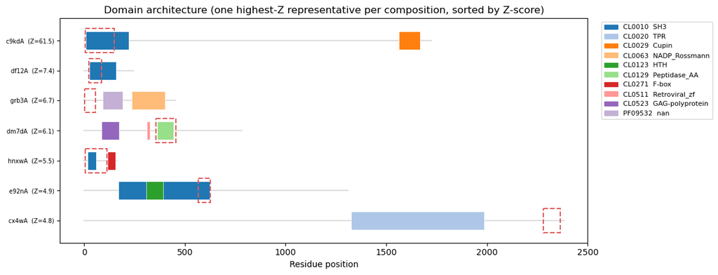

```python
# Domain architecture cartoons
project.viz.architecture('dom_1_FOLD', renderer='matplotlib', pfam_col='clan_domains')
```

dom_2_FOLD (n=111)

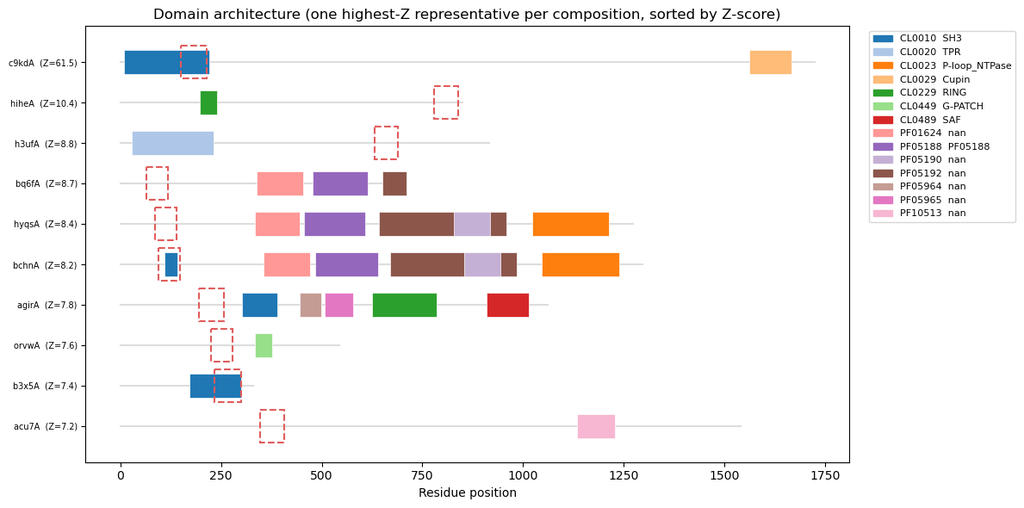

```python
# Domain architecture cartoons
project.viz.architecture('dom_2_FOLD', renderer='matplotlib', pfam_col='clan_domains')
```

dom_3_FOLD (n=18)

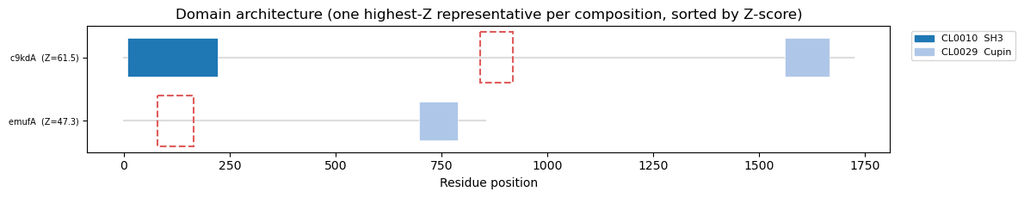

```python
# Domain architecture cartoons
project.viz.architecture('dom_3_FOLD', renderer='matplotlib', pfam_col='clan_domains')
```

dom_4_FOLD (n=51)

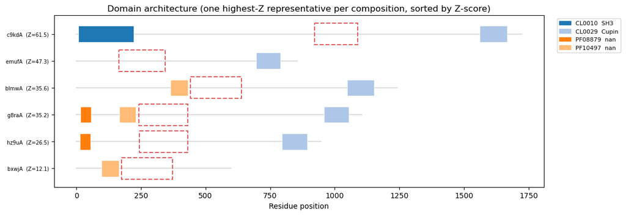

```python
# Domain architecture cartoons
project.viz.architecture('dom_4_FOLD', renderer='matplotlib', pfam_col='clan_domains')
```

dom_5_FOLD (n=1176)

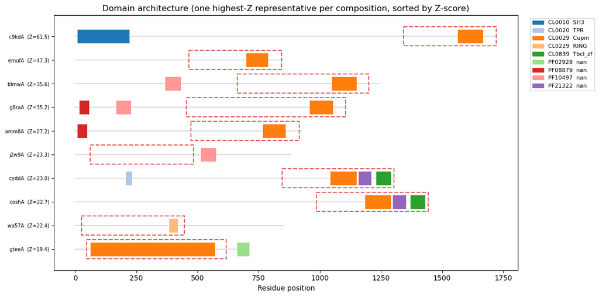

```python
# Domain architecture cartoons
project.viz.architecture('dom_5_FOLD', renderer='matplotlib', pfam_col='clan_domains')
```

## Where do the domain populations fall in the scatterplot?

dom_1_FOLD

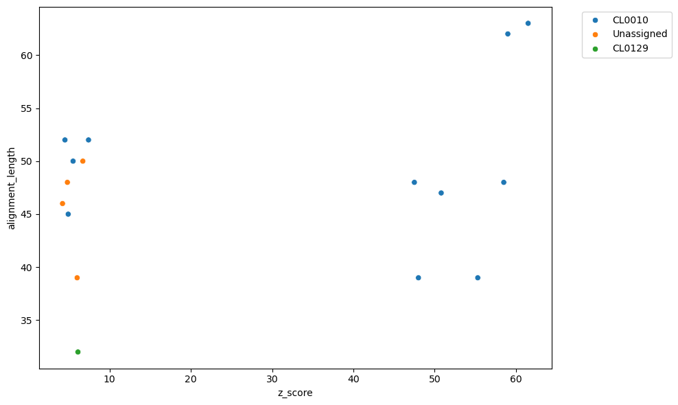

dom_2_FOLD

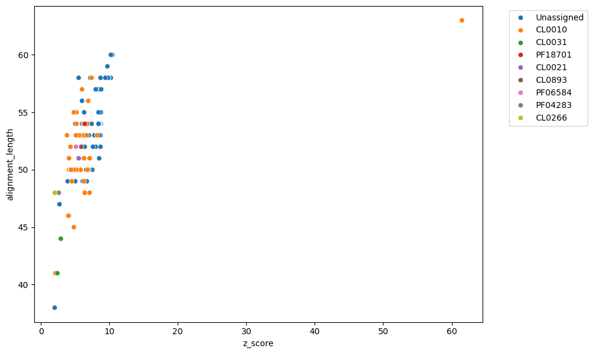

dom_3_FOLD

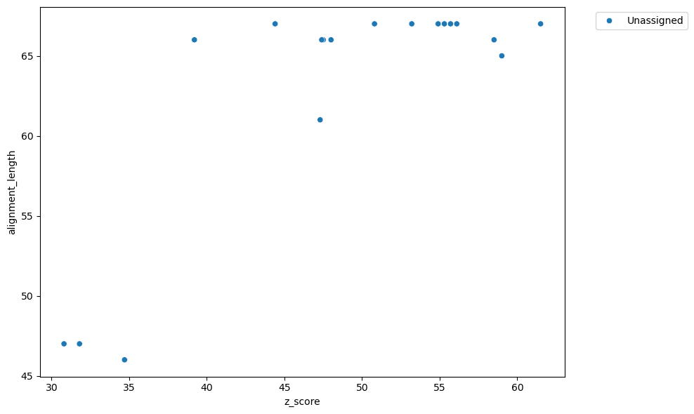

dom_4_FOLD

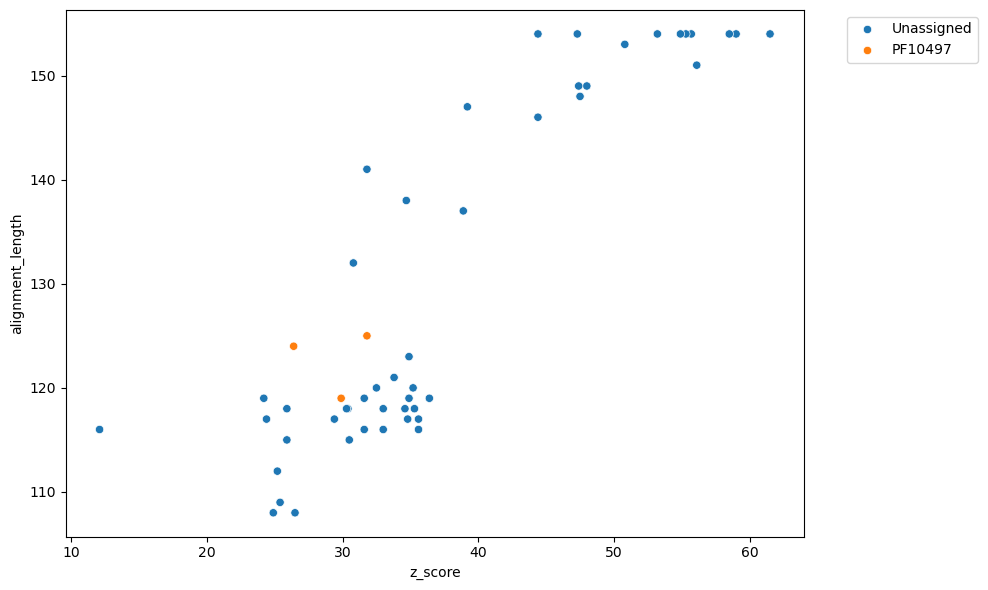

dom_5_FOLD

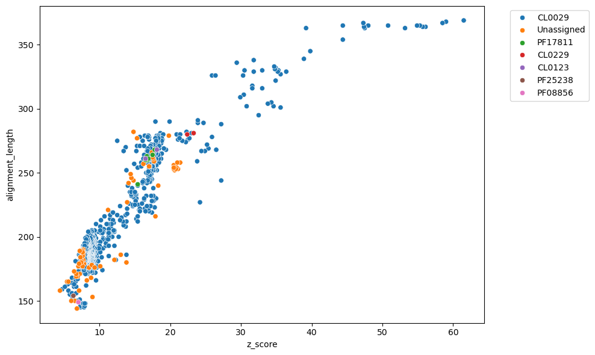

```python
# 3. Scatterplot colored by Pfam categories. Pool more distant Pfam categories as 'Other'
def _scatterplot(view_name):
    show_heading(view_name)
    df = project.views[view_name][['alignment_length', 'z_score', 'clan', 'pfam']].copy()
    df["pfam_label"] = daliscope.analysis.pfam_stats.top_category_label(df, "pfam", k=10)
    df["clan_label"] = daliscope.analysis.pfam_stats.top_category_label(df, "clan", k=10)
    display(daliscope.optics.histograms.plot_scatter(df, x='z_score', y='alignment_length', color='clan_label', engine='matplot',))

for i in [1,2,3,4,5]:
    view_name = f'dom_{i}_FOLD'
    _scatterplot(view_name)
```

# What sequence and functional features characterize the domain populations?

Sequence logos and functional annotation summaries highlight key functional motifs across the five structural domains.

## Sequence Logos

- **Domains 1 & 2 (SH3-like):** Low information content overall, reflecting broad sequence divergence across the fold.
- **Domains 3 & 4:** Characterized by highly conserved cysteines across the structural alignment.
- **Domain 5:** Features a distinct $\text{HxD}\dots\text{H}$ active-site motif.

dom_1_FOLD ( n = 16 )

```
Initializing heavy assets...
```

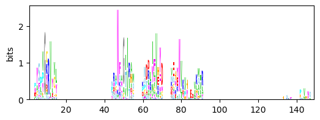

dom_2_FOLD ( n = 111 )

```
Initializing heavy assets...
```

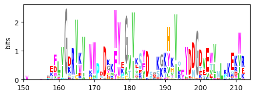

dom_3_FOLD ( n = 18 )

```
Initializing heavy assets...
```

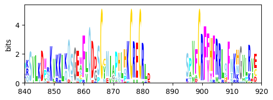

dom_4_FOLD ( n = 51 )

```
Initializing heavy assets...
```

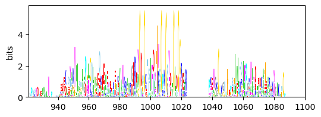

dom_5_FOLD ( n = 1176 )

```
Initializing heavy assets...
```

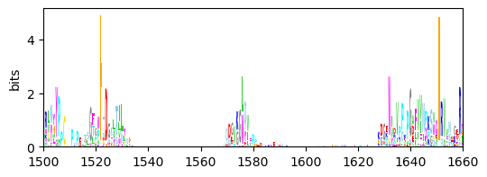

```python
## Sequence Logos
project.viz.plot_msa("dom_1_FOLD", 1, 149)
project.viz.plot_msa("dom_2_FOLD", 150, 214)
project.viz.plot_msa("dom_3_FOLD", 840, 920)
project.viz.plot_msa("dom_4_FOLD", 921, 1100)
project.viz.plot_msa("dom_5_FOLD", 1500, 1660)
```

# Is there a conserved active/binding site in your structure?

*Map the conserved residues in the 3-D structure*

Above, sequence logos shows conserved cysteines and histidines, and a putative catalytic signature. Here, we search for potential metal binding sites by checking side chain geometry in the Query structure. Then, we highlight the identified sites in the 3D structure.

```python
# Check metal binding sites in Query. Requires full coordinates.
results = daliscope.analysis.CH_cluster.evaluate_cys_his_sites(project.query_pdb_str)
daliscope.analysis.CH_cluster.print_report(results)
```

```
Disulfide bonds found: 0

Candidate metal-binding clusters: 4
  [high] Cys4 — CYS867, CYS877, CYS880, CYS900
      pairwise range: 3.58-4.97 A, mean/std dist to centroid: 2.5/0.26 A
  [high] Cys3His1 — CYS962, HIS1075, CYS1087, CYS1089
      pairwise range: 3.51-4.64 A, mean/std dist to centroid: 2.5/0.17 A
  [high] Cys4 — CYS994, CYS997, CYS1016, CYS1019
      pairwise range: 3.61-3.97 A, mean/std dist to centroid: 2.32/0.08 A
  [high] Cys3His1 — CYS1008, CYS1011, CYS1045, HIS1051
      pairwise range: 3.26-4.12 A, mean/std dist to centroid: 2.27/0.23 A
```

```python
# Positions identified as metal-binding or active site candidates
important_residues = [1523, 1525, 1652, 867, 877, 880, 900, 962, 1075, 1087, 1089, 994, 997, 1016, 1019, 1008, 1011, 1045, 1051]

# Highlight candidate metal binding residues and active site
prop = {}
for i in important_residues[0:3]: prop[i] = 5   # domain 5 active site
for i in important_residues[3:7]: prop[i] = 4   # metal binding candidate
for i in important_residues[7:11]: prop[i] = 3  # metal binding candidate
for i in important_residues[11:15]: prop[i] = 2 # metal binding candidate
for i in important_residues[15:19]: prop[i] = 1  # metal binding candidate

daliscope.optics.py3Dmol_viewer.show_structure(
                    project.query_pdb_str,
                    important_residues,
                    property_dict=prop,
                    width=800,
                    height=600,
                    backbone_radius=0.18,
                    ca_radius=0.28,
                    highlight_scale=1.8)
```

3Dmol.js failed to load for some reason. Please check your browser console for error messages.

> The AlphaFold model has built in four potential metal binding sites with C4 or C3H composition. The side chains are oriented for tetrahedral coordination of a metal ion. The CxxC spacing of cysteines along the sequence is characteristic of a "cysteine knuckle". The geometrical check confirmed bond lengths in valid range. The active site (red) has two histidines and an aspartate.